# T12

### Escuela Politécnica Nacional

**Nombre:** Marco Marcillo

**Tema:** [Tarea 12] Ejercicios Unidad 05-A | ODE Método de Euler

**Repositorio GIT:** https://github.com/Alejandro0122/MN_PERSONAL

1. Use el método de Euler para aproximar las soluciones para cada uno de los siguientes problemas de valor inicial

a. 𝑦′ = 𝑡ℯ 3𝑡 − 2𝑦, 0 ≤ 𝑡 ≤ 1, 𝑦(0) = 0, con ℎ = 0.5

b. 𝑦′ = 1 + (𝑡 − 𝑦)2, 2 ≤ 𝑡 ≤ 3, 𝑦(2) = 1, con ℎ = 0.5

c. 𝑦′ = 1 + 𝑦𝑡 ⁄ , 1 ≤ 𝑡 ≤ 2, 𝑦(1) = 2, con ℎ = 0.25

d. 𝑦′ = cos 2𝑡 + sen 3𝑡, 0 ≤ 𝑡 ≤ 1, 𝑦(0) = 1, con ℎ = 0.25

```python
import numpy as np
import pandas as pd

def euler_method(f, t0, y0, h, t_end):
    """
    Resuelve una ecuación diferencial ordinaria usando el método de Euler.

    Args:
        f (function): La función f(t, y) que define la EDO, y' = f(t, y).
        t0 (float): El valor inicial de t.
        y0 (float): El valor inicial de y.
        h (float): El tamaño del paso.
        t_end (float): El valor final de t.

    Returns:
        pd.DataFrame: Un DataFrame con los valores de 't' y 'y' calculados.
    """

    # Calcular el número de pasos. Usamos round para evitar problemas de coma flotante.
    num_steps = int(round((t_end - t0) / h))

    # Inicializar las listas para los resultados
    t_values = [t0]
    y_values = [y0]

    # Inicializar las variables para la iteración
    t_current = t0
    y_current = y0

    # Imprimir el encabezado de la tabla
    print(f"\n--- Método de Euler de t={t0} a t={t_end} con paso h={h} ---\n")
    print(f"{'Paso':<5} | {'t':<10} | {'y':<15}")
    print("-" * 35)
    print(f"{0:<5} | {t_current:<10.4f} | {y_current:<15.6f}")

    # Bucle principal del método de Euler
    for i in range(num_steps):
        # Fórmula de Euler: y_n+1 = y_n + h * f(t_n, y_n)
        y_next = y_current + h * f(t_current, y_current)
        t_next = t_current + h

        # Actualizar los valores y guardar en las listas
        y_current = y_next
        t_current = t_next
        t_values.append(t_current)
        y_values.append(y_current)

        # Imprimir el resultado del paso actual
        print(f"{i+1:<5} | {t_current:<10.4f} | {y_current:<15.6f}")

    return pd.DataFrame({"t": t_values, "y": y_values})
```

```python
# --- Ejecución de los casos de prueba ---

# a. y' = t * e^(3t) - 2y
print("\n--- Resolviendo la Ecuación (a) ---")
f_a = lambda t, y: t * np.exp(3 * t) - 2 * y
df_a = euler_method(f_a, t0=0, y0=0, h=0.5, t_end=1)
print("\nDataFrame para la Ecuación (a):")
print(df_a)

print("\n" + "="*50 + "\n")

# b. y' = 1 + (t - y)^2
print("\n--- Resolviendo la Ecuación (b) ---")
f_b = lambda t, y: 1 + (t - y)**2
df_b = euler_method(f_b, t0=2, y0=1, h=0.5, t_end=3)
print("\nDataFrame para la Ecuación (b):")
print(df_b)

print("\n" + "="*50 + "\n")
```

[output not shown]

[output cut: 25 more lines]

[output not shown]

```python
# c. y' = 1 + y / t
print("\n--- Resolviendo la Ecuación (c) ---")
f_c = lambda t, y: 1 + y / t
df_c = euler_method(f_c, t0=1, y0=2, h=0.25, t_end=2)
print("\nDataFrame para la Ecuación (c):")
print(df_c)

print("\n" + "="*50 + "\n")

# d. y' = cos(2t) + sin(3t)
print("\n--- Resolviendo la Ecuación (d) ---")
f_d = lambda t, y: np.cos(2 * t) + np.sin(3 * t)
df_d = euler_method(f_d, t0=0, y0=1, h=0.25, t_end=1)
print("\nDataFrame para la Ecuación (d):")
print(df_d)
```

```
--- Resolviendo la Ecuación (c) ---

--- Método de Euler de t=1 a t=2 con paso h=0.25 ---

Paso  | t          | y
-----------------------------------
0     | 1.0000     | 2.000000
1     | 1.2500     | 2.750000
2     | 1.5000     | 3.550000
3     | 1.7500     | 4.391667
4     | 2.0000     | 5.269048

DataFrame para la Ecuación (c):
      t         y
0  1.00  2.000000
1  1.25  2.750000
2  1.50  3.550000
3  1.75  4.391667
4  2.00  5.269048

==================================================


--- Resolviendo la Ecuación (d) ---

--- Método de Euler de t=0 a t=1 con paso h=0.25 ---

Paso  | t          | y
-----------------------------------
0     | 0.0000     | 1.000000
1     | 0.2500     | 1.250000
2     | 0.5000     | 1.639805
3     | 0.7500     | 2.024255
4     | 1.0000     | 2.236457

DataFrame para la Ecuación (d):
      t         y
0  0.00  1.000000
1  0.25  1.250000
2  0.50  1.639805
3  0.75  2.024255
4  1.00  2.236457
```

2. Las soluciones reales para los problemas de valor inicial en el ejercicio 1 se proporcionan aquí. Compare el error real en cada paso.

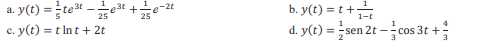

```python
import numpy as np
import pandas as pd

# Método de Euler
def euler_method(f, t0, y0, h, t_end):
    """
    Resuelve una ecuación diferencial ordinaria usando el método de Euler.

    Args:
        f (function): La función f(t, y) que define la EDO, y' = f(t, y).
        t0 (float): El valor inicial de t.
        y0 (float): El valor inicial de y.
        h (float): El tamaño del paso.
        t_end (float): El valor final de t.

    Returns:
        pd.DataFrame: Un DataFrame con los valores de 't' y 'y' calculados.
    """
    steps = int((t_end - t0) / h) + 1
    t_values = [t0]
    y_values = [y0]
    t = t0
    y = y0
    for _ in range(steps - 1):
        y += h * f(t, y)
        t += h
        t_values.append(t)
        y_values.append(y)
    return pd.DataFrame({"t": t_values, "y": y_values})

# Funciones de derivadas (problema 1)
f_a = lambda t, y: t * np.exp(3 * t) - 2 * y
f_b = lambda t, y: 1 + (t - y)**2
f_c = lambda t, y: 1 + y / t
f_d = lambda t, y: np.cos(2 * t) + np.sin(3 * t)

# Aplicar método de Euler a cada problema
df_a = euler_method(f_a, 0, 0, 0.5, 1)
df_b = euler_method(f_b, 2, 1, 0.5, 3)
df_c = euler_method(f_c, 1, 2, 0.25, 2)
df_d = euler_method(f_d, 0, 1, 0.25, 1)

# Funciones exactas (problema 2)
def exact_a(t):
    return (1/5)*t*np.exp(3*t) - (1/25)*np.exp(3*t) + (1/25)*np.exp(-2*t)

def exact_b(t):
    return t + 1/(1 - t)

def exact_c(t):
    return t * np.log(t) + 2 * t

def exact_d(t):
    return 0.5 * np.sin(2*t) - (1/3) * np.cos(3*t) + 4/3

# Comparar con solución exacta
def comparar(df, exact_func):
    df["y_exacta"] = exact_func(df["t"])
    df["error"] = np.abs(df["y"] - df["y_exacta"])
    return df[["t", "y", "y_exacta", "error"]]

# Calcular errores
df_a_err = comparar(df_a, exact_a)
df_b_err = comparar(df_b, exact_b)
df_c_err = comparar(df_c, exact_c)
df_d_err = comparar(df_d, exact_d)

# Mostrar resultados
print("\n--- a. Error Método de Euler ---")
print(df_a_err)
print("\n--- b. Error Método de Euler ---")
print(df_b_err)
print("\n--- c. Error Método de Euler ---")
print(df_c_err)
print("\n--- d. Error Método de Euler ---")
print(df_d_err)
```

```
--- a. Error Método de Euler ---
     t         y  y_exacta     error
0  0.0  0.000000  0.000000  0.000000
1  0.5  0.000000  0.283617  0.283617
2  1.0  1.120422  3.219099  2.098677

--- b. Error Método de Euler ---
     t      y  y_exacta     error
0  2.0  1.000  1.000000  0.000000
1  2.5  2.000  1.833333  0.166667
2  3.0  2.625  2.500000  0.125000

--- c. Error Método de Euler ---
      t         y  y_exacta     error
0  1.00  2.000000  2.000000  0.000000
1  1.25  2.750000  2.778929  0.028929
2  1.50  3.550000  3.608198  0.058198
3  1.75  4.391667  4.479328  0.087661
4  2.00  5.269048  5.386294  0.117247

--- d. Error Método de Euler ---
      t         y  y_exacta     error
0  0.00  1.000000  1.000000  0.000000
1  0.25  1.250000  1.329150  0.079150
2  0.50  1.639805  1.730490  0.090684
3  0.75  2.024255  2.041472  0.017217
4  1.00  2.236457  2.117980  0.118478
```

3. Utilice el método de Euler para aproximar las soluciones para cada uno de los siguientes problemas de valor inicial

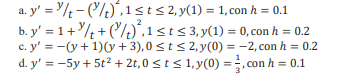

```python
import numpy as np
import pandas as pd

# Método de Euler
def euler_method(f, t0, y0, h, t_end):
    """
    Resuelve una ecuación diferencial ordinaria usando el método de Euler.

    Args:
        f (function): La función f(t, y) que define la EDO, y' = f(t, y).
        t0 (float): El valor inicial de t.
        y0 (float): El valor inicial de y.
        h (float): El tamaño del paso.
        t_end (float): El valor final de t.

    Returns:
        pd.DataFrame: Un DataFrame con los valores de 't' y 'y' calculados.
    """
    steps = int((t_end - t0) / h) + 1
    t_values = [t0]
    y_values = [y0]
    t = t0
    y = y0
    for _ in range(steps - 1):
        y += h * f(t, y)
        t += h
        t_values.append(t)
        y_values.append(y)
    return pd.DataFrame({"t": t_values, "y": y_values})

# Definimos las funciones de derivada de cada inciso

# a. y' = y/t - (y/t)^2, t in [1, 2], y(1) = 1, h = 0.1
f_a = lambda t, y: (y / t) - (y / t) ** 2
df_a = euler_method(f_a, t0=1, y0=1, h=0.1, t_end=2)

# b. y' = 1 + y/t + (y/t)^2, t in [1, 3], y(1) = 0, h = 0.2
f_b = lambda t, y: 1 + y / t + (y / t) ** 2
df_b = euler_method(f_b, t0=1, y0=0, h=0.2, t_end=3)

# c. y' = -(y + 1)(y + 3), t in [0, 2], y(0) = -2, h = 0.2
f_c = lambda t, y: - (y + 1) * (y + 3)
df_c = euler_method(f_c, t0=0, y0=-2, h=0.2, t_end=2)

# d. y' = -5y + 5t^2 + 2t, t in [0, 1], y(0) = 1/3, h = 0.1
f_d = lambda t, y: -5 * y + 5 * t**2 + 2 * t
df_d = euler_method(f_d, t0=0, y0=1/3, h=0.1, t_end=1)

# Mostrar los resultados
print("\n--- a. Resultado Método de Euler ---")
print(df_a)
print("\n--- b. Resultado Método de Euler ---")
print(df_b)
print("\n--- c. Resultado Método de Euler ---")
print(df_c)
print("\n--- d. Resultado Método de Euler ---")
print(df_d)
```

```
--- a. Resultado Método de Euler ---
      t         y
0   1.0  1.000000
1   1.1  1.000000
2   1.2  1.008264
3   1.3  1.021689
4   1.4  1.038515
5   1.5  1.057668
6   1.6  1.078461
7   1.7  1.100432
8   1.8  1.123262
9   1.9  1.146724
10  2.0  1.170652

--- b. Resultado Método de Euler ---
```

[output cut: 40 more lines]

4. Aquí se dan las soluciones reales para los problemas de valor inicial en el ejercicio 3. Calcule el error real en las aproximaciones del ejercicio 3.

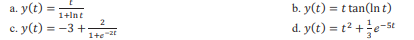

```python
import numpy as np
import pandas as pd

# Método de Euler
def euler_method(f, t0, y0, h, t_end):
    """
    Resuelve una ecuación diferencial ordinaria usando el método de Euler.

    Args:
        f (function): La función f(t, y) que define la EDO, y' = f(t, y).
        t0 (float): El valor inicial de t.
        y0 (float): El valor inicial de y.
        h (float): El tamaño del paso.
        t_end (float): El valor final de t.

    Returns:
        pd.DataFrame: Un DataFrame con los valores de 't' y 'y' calculados.
    """
    steps = int((t_end - t0) / h) + 1
    t_values = [t0]
    y_values = [y0]
    t = t0
    y = y0
    for _ in range(steps - 1):
        y += h * f(t, y)
        t += h
        t_values.append(t)
        y_values.append(y)
    return pd.DataFrame({"t": t_values, "y_aprox": y_values})

# Aproximaciones del ejercicio 3

# a. y' = y/t - (y/t)^2, t in [1, 2], y(1) = 1, h = 0.1
f_a = lambda t, y: (y / t) - (y / t) ** 2
df_a = euler_method(f_a, t0=1, y0=1, h=0.1, t_end=2)

# b. y' = 1 + y/t + (y/t)^2, t in [1, 3], y(1) = 0, h = 0.2
f_b = lambda t, y: 1 + y / t + (y / t) ** 2
df_b = euler_method(f_b, t0=1, y0=0, h=0.2, t_end=3)

# c. y' = -(y + 1)(y + 3), t in [0, 2], y(0) = -2, h = 0.2
f_c = lambda t, y: - (y + 1) * (y + 3)
df_c = euler_method(f_c, t0=0, y0=-2, h=0.2, t_end=2)

# d. y' = -5y + 5t^2 + 2t, t in [0, 1], y(0) = 1/3, h = 0.1
f_d = lambda t, y: -5 * y + 5 * t**2 + 2 * t
df_d = euler_method(f_d, t0=0, y0=1/3, h=0.1, t_end=1)

# Soluciones exactas del ejercicio 4
def exact_a(t):
    return t / (1 + np.log(t))
def exact_b(t):
    return t * np.tan(np.log(t))
def exact_c(t):
    return -3 + 2 / (1 + np.exp(-2 * t))
def exact_d(t):
    return t**2 + (1/3) * np.exp(-5 * t)

# Comparación función
def comparar(df, exact_func):
    df["y_exacta"] = exact_func(df["t"])
    df["error"] = np.abs(df["y_aprox"] - df["y_exacta"])
    return df
```

```python
# Comparar cada resultado
df_a_res = comparar(df_a, exact_a)
df_b_res = comparar(df_b, exact_b)
df_c_res = comparar(df_c, exact_c)
df_d_res = comparar(df_d, exact_d)

# Mostrar resultados
pd.set_option("display.precision", 6)
print("\n--- a. Comparación ---")
print(df_a_res)
print("\n--- b. Comparación ---")
print(df_b_res)
print("\n--- c. Comparación ---")
print(df_c_res)
print("\n--- d. Comparación ---")
print(df_d_res)
```

```
--- a. Comparación ---
      t   y_aprox  y_exacta     error
0   1.0  1.000000  1.000000  0.000000
1   1.1  1.000000  1.004282  0.004282
2   1.2  1.008264  1.014952  0.006688
3   1.3  1.021689  1.029814  0.008124
4   1.4  1.038515  1.047534  0.009019
5   1.5  1.057668  1.067262  0.009594
6   1.6  1.078461  1.088433  0.009972
7   1.7  1.100432  1.110655  0.010223
8   1.8  1.123262  1.133654  0.010392
9   1.9  1.146724  1.157228  0.010505
10  2.0  1.170652  1.181232  0.010581

--- b. Comparación ---
```

[output cut: 40 more lines]

5. Utilice los resultados del ejercicio 3 y la interpolación lineal para aproximar los siguientes valores de 𝑦(𝑡). Compare las aproximaciones asignadas para los valores reales obtenidos mediante las funciones determinadas en el ejercicio 4.

a. 𝑦(0.25) y 𝑦(0.93)

b. 𝑦(𝑡) = 𝑦(1.25) y 𝑦(1.93)

c. 𝑦(2.10) y 𝑦(2.75)

d. 𝑦(𝑡) = 𝑦(0.54) y 𝑦(0.94)

```python
import numpy as np
import pandas as pd

# Método de Euler
def euler_method(f, t0, y0, h, t_end):
    """
    Resuelve una ecuación diferencial ordinaria usando el método de Euler.

    Args:
        f (function): La función f(t, y) que define la EDO, y' = f(t, y).
        t0 (float): El valor inicial de t.
        y0 (float): El valor inicial de y.
        h (float): El tamaño del paso.
        t_end (float): El valor final de t.

    Returns:
        pd.DataFrame: Un DataFrame con los valores de 't' y 'y' calculados.
    """
    steps = int((t_end - t0) / h) + 1
    t_values = [t0]
    y_values = [y0]
    t = t0
    y = y0
    for _ in range(steps - 1):
        y += h * f(t, y)
        t += h
        t_values.append(t)
        y_values.append(y)
    return pd.DataFrame({"t": t_values, "y_aprox": y_values})

# Funciones del ejercicio 3
f_a = lambda t, y: (y / t) - (y / t)**2
f_b = lambda t, y: 1 + (y / t) + (y / t)**2
f_c = lambda t, y: -(y + 1)*(y + 3)
f_d = lambda t, y: -5*y + 5*t**2 + 2*t

# Aproximaciones con Euler
df_a = euler_method(f_a, t0=1, y0=1, h=0.1, t_end=2)
df_b = euler_method(f_b, t0=1, y0=0, h=0.2, t_end=3)
df_c = euler_method(f_c, t0=0, y0=-2, h=0.2, t_end=2)
df_d = euler_method(f_d, t0=0, y0=1/3, h=0.1, t_end=1)

# Interpolación lineal
def interpolar(df, t_eval):
    return np.interp(t_eval, df["t"], df["y_aprox"])

# Soluciones exactas del ejercicio 4
def exact_a(t): return t / (1 + np.log(t))
def exact_b(t): return t * np.tan(np.log(t))
def exact_c(t): return -3 + 2 / (1 + np.exp(-2 * t))
def exact_d(t): return t**2 + (1/3) * np.exp(-5 * t)

# Puntos a interpolar
puntos = {
    'a': [0.25, 0.93],
    'b': [1.25, 1.93],
    'c': [2.10, 2.75],
    'd': [0.54, 0.94]
}

# Asociación de incisos
casos = {
    'a': (df_c, exact_c),  # [0,2]
    'b': (df_a, exact_a),  # [1,2]
    'c': (df_b, exact_b),  # [1,3]
    'd': (df_d, exact_d),  # [0,1]
}

# Mostrar resultados
for letra in ['a', 'b', 'c', 'd']:
    df, f_exacta = casos[letra]
    print(f"\n--- Inciso {letra.upper()} ---")
    for t_eval in puntos[letra]:
        y_interp = interpolar(df, t_eval)
        y_real = f_exacta(t_eval)
        error = abs(y_interp - y_real)
        print(f"t = {t_eval:.2f} | y_interp = {y_interp:.6f} | y_real = {y_real:.6f} | error = {error:.6f}")
```

```
--- Inciso A ---
t = 0.25 | y_interp = -1.752000 | y_real = -1.755081 | error = 0.003081
t = 0.93 | y_interp = -1.235121 | y_real = -1.269406 | error = 0.034285

--- Inciso B ---
t = 1.25 | y_interp = 1.014977 | y_real = 1.021957 | error = 0.006980
t = 1.93 | y_interp = 1.153902 | y_real = 1.164390 | error = 0.010488

--- Inciso C ---
t = 2.10 | y_interp = 1.660756 | y_real = 1.924962 | error = 0.264206
t = 2.75 | y_interp = 3.526160 | y_real = 4.394170 | error = 0.868010

--- Inciso D ---
t = 0.54 | y_interp = 0.282833 | y_real = 0.314002 | error = 0.031169
t = 0.94 | y_interp = 0.866552 | y_real = 0.886632 | error = 0.020080
```

6. Use el método de Taylor de orden 2 para aproximar las soluciones para cada uno de los siguientes problemas de valor inicial.

a. 𝑦′ = 𝑡ℯ 3𝑡 − 2𝑦, 0 ≤ 𝑡 ≤ 1, 𝑦(0) = 0, con ℎ = 0.5

b. 𝑦′ = 1 + (𝑡 − 𝑦)2 , 2 ≤ 𝑡 ≤ 3, 𝑦(2) = 1, con ℎ = 0.5

c. 𝑦′ = 1 + 𝑦𝑡 ⁄ , 1 ≤ 𝑡 ≤ 2, 𝑦(1) = 2, con ℎ = 0.25

d. 𝑦′ = cos 2𝑡 + sen 3𝑡, 0 ≤ 𝑡 ≤ 1, 𝑦(0) = 1, con ℎ = 0.25

```python
import numpy as np
import pandas as pd

# Método de Euler
def euler_method(f, t0, y0, h, t_end):
    """
    Resuelve una ecuación diferencial ordinaria usando el método de Euler.

    Args:
        f (function): La función f(t, y) que define la EDO, y' = f(t, y).
        t0 (float): El valor inicial de t.
        y0 (float): El valor inicial de y.
        h (float): El tamaño del paso.
        t_end (float): El valor final de t.

    Returns:
        pd.DataFrame: Un DataFrame con los valores de 't' y 'y' calculados.
    """
    steps = int((t_end - t0) / h) + 1
    t_values = [t0]
    y_values = [y0]
    t = t0
    y = y0
    for _ in range(steps - 1):
        y += h * f(t, y)
        t += h
        t_values.append(t)
        y_values.append(y)
    return pd.DataFrame({"t": t_values, "y_aprox": y_values})

# Funciones del ejercicio 3
f_a = lambda t, y: (y / t) - (y / t)**2
f_b = lambda t, y: 1 + (y / t) + (y / t)**2
f_c = lambda t, y: -(y + 1)*(y + 3)
f_d = lambda t, y: -5*y + 5*t**2 + 2*t

# Aproximaciones con Euler
df_a_euler = euler_method(f_a, t0=1, y0=1, h=0.1, t_end=2)
df_b_euler = euler_method(f_b, t0=1, y0=0, h=0.2, t_end=3)
df_c_euler = euler_method(f_c, t0=0, y0=-2, h=0.2, t_end=2)
df_d_euler = euler_method(f_d, t0=0, y0=1/3, h=0.1, t_end=1)

# Interpolación lineal
def interpolar(df, t_eval):
    return np.interp(t_eval, df["t"], df["y_aprox"])

# Soluciones exactas del ejercicio 4
def exact_a(t): return t / (1 + np.log(t))
def exact_b(t): return t * np.tan(np.log(t))
def exact_c(t): return -3 + 2 / (1 + np.exp(-2 * t))
def exact_d(t): return t**2 + (1/3) * np.exp(-5 * t)

# Puntos a interpolar
puntos = {
    'a': [0.25, 0.93],
    'b': [1.25, 1.93],
    'c': [2.10, 2.75],
    'd': [0.54, 0.94]
}

# Asociación de incisos
casos = {
    'a': (df_c_euler, exact_c),  # [0,2]
    'b': (df_a_euler, exact_a),  # [1,2]
    'c': (df_b_euler, exact_b),  # [1,3]
    'd': (df_d_euler, exact_d),  # [0,1]
}

# Mostrar resultados de Euler
print("\n--- Resultados Método de Euler ---")
for letra in ['a', 'b', 'c', 'd']:
    df, f_exacta = casos[letra]
    print(f"\nInciso {letra.upper()}:")
    for t_eval in puntos[letra]:
        y_interp = interpolar(df, t_eval)
        y_real = f_exacta(t_eval)
        error = abs(y_interp - y_real)
        print(f"t = {t_eval:.2f} | y_interp = {y_interp:.6f} | y_real = {y_real:.6f} | error = {error:.6f}")

# Método de Taylor de orden 2
def taylor_orden_2(f, df_dt, df_dy, t0, y0, h, t_end):
    t_values = [t0]
    y_values = [y0]
    t = t0
    y = y0
    steps = int((t_end - t0) / h)
    for _ in range(steps):
        f_val = f(t, y)
        df_val = df_dt(t, y) + df_dy(t, y) * f_val
        y = y + h * f_val + (h**2 / 2) * df_val
        t = t + h
        t_values.append(t)
        y_values.append(y)
    return pd.DataFrame({"t": t_values, "y_aprox": y_values})

# a. y' = t * e^(3t) - 2y
f_a_taylor = lambda t, y: t * np.exp(3 * t) - 2 * y
dfdt_a = lambda t, y: (1 + 3 * t) * np.exp(3 * t)
dfdy_a = lambda t, y: -2
df_a_taylor = taylor_orden_2(f_a_taylor, dfdt_a, dfdy_a, t0=0, y0=0, h=0.5, t_end=1)

# b. y' = 1 + (t - y)^2
f_b_taylor = lambda t, y: 1 + (t - y)**2
dfdt_b = lambda t, y: 2 * (t - y)
dfdy_b = lambda t, y: -2 * (t - y)
df_b_taylor = taylor_orden_2(f_b_taylor, dfdt_b, dfdy_b, t0=2, y0=1, h=0.5, t_end=3)

# c. y' = 1 + y / t
f_c_taylor = lambda t, y: 1 + y / t
dfdt_c = lambda t, y: -y / (t**2)
dfdy_c = lambda t, y: 1 / t
df_c_taylor = taylor_orden_2(f_c_taylor, dfdt_c, dfdy_c, t0=1, y0=2, h=0.25, t_end=2)

# d. y' = cos(2t) + sin(3t)
f_d_taylor = lambda t, y: np.cos(2 * t) + np.sin(3 * t)
dfdt_d = lambda t, y: -2 * np.sin(2 * t) + 3 * np.cos(3 * t)
dfdy_d = lambda t, y: 0
df_d_taylor = taylor_orden_2(f_d_taylor, dfdt_d, dfdy_d, t0=0, y0=1, h=0.25, t_end=1)

# Mostrar resultados
print("\n--- Resultados Método de Taylor Orden 2 ---")
for letra, df in zip("abcd", [df_a_taylor, df_b_taylor, df_c_taylor, df_d_taylor]):
    print(f"\nInciso {letra.upper()}:")
    print(df)
```

```
--- Resultados Método de Euler ---

Inciso A:
t = 0.25 | y_interp = -1.752000 | y_real = -1.755081 | error = 0.003081
t = 0.93 | y_interp = -1.235121 | y_real = -1.269406 | error = 0.034285

Inciso B:
t = 1.25 | y_interp = 1.014977 | y_real = 1.021957 | error = 0.006980
t = 1.93 | y_interp = 1.153902 | y_real = 1.164390 | error = 0.010488

Inciso C:
t = 2.10 | y_interp = 1.660756 | y_real = 1.924962 | error = 0.264206
t = 2.75 | y_interp = 3.526160 | y_real = 4.394170 | error = 0.868010

Inciso D:
t = 0.54 | y_interp = 0.282833 | y_real = 0.314002 | error = 0.031169
t = 0.94 | y_interp = 0.866552 | y_real = 0.886632 | error = 0.020080

--- Resultados Método de Taylor Orden 2 ---

Inciso A:
     t   y_aprox
0  0.0  0.000000
1  0.5  0.125000
2  1.0  2.023239

Inciso B:
     t   y_aprox
0  2.0  1.000000
1  2.5  1.750000
2  3.0  2.425781

Inciso C:
      t   y_aprox
0  1.00  2.000000
1  1.25  2.781250
2  1.50  3.612500
3  1.75  4.485417
4  2.00  5.394048

Inciso D:
      t   y_aprox
0  0.00  1.000000
1  0.25  1.343750
2  0.50  1.772187
3  0.75  2.110676
4  1.00  2.201644
```

7. Repita el ejercicio 6 con el método de Taylor de orden 4

```python
import numpy as np
import pandas as pd

# Método de Euler
def euler_method(f, t0, y0, h, t_end):
    """
    Resuelve una ecuación diferencial ordinaria usando el método de Euler.

    Args:
        f (function): La función f(t, y) que define la EDO, y' = f(t, y).
        t0 (float): El valor inicial de t.
        y0 (float): El valor inicial de y.
        h (float): El tamaño del paso.
        t_end (float): El valor final de t.

    Returns:
        pd.DataFrame: Un DataFrame con los valores de 't' y 'y' calculados.
    """
    steps = int((t_end - t0) / h) + 1
    t_values = [t0]
    y_values = [y0]
    t = t0
    y = y0
    for _ in range(steps - 1):
        y += h * f(t, y)
        t += h
        t_values.append(t)
        y_values.append(y)
    return pd.DataFrame({"t": t_values, "y_aprox": y_values})

# Funciones del ejercicio 3
f_a = lambda t, y: (y / t) - (y / t)**2
f_b = lambda t, y: 1 + (y / t) + (y / t)**2
f_c = lambda t, y: -(y + 1)*(y + 3)
f_d = lambda t, y: -5*y + 5*t**2 + 2*t

# Aproximaciones con Euler
df_a_euler = euler_method(f_a, t0=1, y0=1, h=0.1, t_end=2)
df_b_euler = euler_method(f_b, t0=1, y0=0, h=0.2, t_end=3)
df_c_euler = euler_method(f_c, t0=0, y0=-2, h=0.2, t_end=2)
df_d_euler = euler_method(f_d, t0=0, y0=1/3, h=0.1, t_end=1)

# Interpolación lineal
def interpolar(df, t_eval):
    return np.interp(t_eval, df["t"], df["y_aprox"])

# Soluciones exactas del ejercicio 4
def exact_a(t): return t / (1 + np.log(t))
def exact_b(t): return t * np.tan(np.log(t))
def exact_c(t): return -3 + 2 / (1 + np.exp(-2 * t))
def exact_d(t): return t**2 + (1/3) * np.exp(-5 * t)

# Puntos a interpolar
puntos = {
    'a': [0.25, 0.93],
    'b': [1.25, 1.93],
    'c': [2.10, 2.75],
    'd': [0.54, 0.94]
}

# Asociación de incisos
casos = {
    'a': (df_c_euler, exact_c),  # [0,2]
    'b': (df_a_euler, exact_a),  # [1,2]
    'c': (df_b_euler, exact_b),  # [1,3]
    'd': (df_d_euler, exact_d),  # [0,1]
}

# Mostrar resultados de Euler
print("\n--- Resultados Método de Euler ---")
for letra in ['a', 'b', 'c', 'd']:
    df, f_exacta = casos[letra]
    print(f"\nInciso {letra.upper()}:")
    for t_eval in puntos[letra]:
        y_interp = interpolar(df, t_eval)
        y_real = f_exacta(t_eval)
        error = abs(y_interp - y_real)
        print(f"t = {t_eval:.2f} | y_interp = {y_interp:.6f} | y_real = {y_real:.6f} | error = {error:.6f}")

# Método de Taylor de orden 2
def taylor_orden_2(f, df_dt, df_dy, t0, y0, h, t_end):
    t_values = [t0]
    y_values = [y0]
    t = t0
    y = y0
    steps = int((t_end - t0) / h)
    for _ in range(steps):
        f_val = f(t, y)
        df_val = df_dt(t, y) + df_dy(t, y) * f_val
        y = y + h * f_val + (h**2 / 2) * df_val
        t = t + h
        t_values.append(t)
        y_values.append(y)
    return pd.DataFrame({"t": t_values, "y_aprox": y_values})

# a. y' = t * e^(3t) - 2y
f_a_taylor_2 = lambda t, y: t * np.exp(3 * t) - 2 * y
dfdt_a = lambda t, y: (1 + 3 * t) * np.exp(3 * t)
dfdy_a = lambda t, y: -2
df_a_taylor_2 = taylor_orden_2(f_a_taylor_2, dfdt_a, dfdy_a, t0=0, y0=0, h=0.5, t_end=1)

# b. y' = 1 + (t - y)^2
f_b_taylor_2 = lambda t, y: 1 + (t - y)**2
dfdt_b = lambda t, y: 2 * (t - y)
dfdy_b = lambda t, y: -2 * (t - y)
df_b_taylor_2 = taylor_orden_2(f_b_taylor_2, dfdt_b, dfdy_b, t0=2, y0=1, h=0.5, t_end=3)

# c. y' = 1 + y / t
f_c_taylor_2 = lambda t, y: 1 + y / t
dfdt_c = lambda t, y: -y / (t**2)
dfdy_c = lambda t, y: 1 / t
df_c_taylor_2 = taylor_orden_2(f_c_taylor_2, dfdt_c, dfdy_c, t0=1, y0=2, h=0.25, t_end=2)

# d. y' = cos(2t) + sin(3t)
f_d_taylor_2 = lambda t, y: np.cos(2 * t) + np.sin(3 * t)
dfdt_d = lambda t, y: -2 * np.sin(2 * t) + 3 * np.cos(3 * t)
dfdy_d = lambda t, y: 0
df_d_taylor_2 = taylor_orden_2(f_d_taylor_2, dfdt_d, dfdy_d, t0=0, y0=1, h=0.25, t_end=1)

# Mostrar resultados
print("\n--- Resultados Método de Taylor Orden 2 ---")
for letra, df in zip("abcd", [df_a_taylor_2, df_b_taylor_2, df_c_taylor_2, df_d_taylor_2]):
    print(f"\nInciso {letra.upper()}:")
    print(df)

# Método de Taylor de orden 4
def taylor_orden_4(f, f1, f2, f3, t0, y0, h, t_end):
    t_values = [t0]
    y_values = [y0]
    t, y = t0, y0
    steps = int((t_end - t0) / h)

    for _ in range(steps):
        f_val = f(t, y)
        f1_val = f1(t, y)
        f2_val = f2(t, y)
        f3_val = f3(t, y)

        y = y + h * f_val + (h**2 / 2) * f1_val + (h**3 / 6) * f2_val + (h**4 / 24) * f3_val
        t += h
        t_values.append(t)
        y_values.append(y)

    return pd.DataFrame({"t": t_values, "y_aprox": y_values})

# ========== a. y' = t*e^(3t) - 2y ==========

f_a_taylor_4 = lambda t, y: t*np.exp(3*t) - 2*y
f1_a = lambda t, y: (1 + 3*t)*np.exp(3*t) - 2*f_a_taylor_4(t, y)
f2_a = lambda t, y: 6*np.exp(3*t) + 9*(1 + 3*t)*np.exp(3*t) - 2*f1_a(t, y)
f3_a = lambda t, y: (27*(1 + 3*t) + 54)*np.exp(3*t) - 2*f2_a(t, y)

df_a_taylor_4 = taylor_orden_4(f_a_taylor_4, f1_a, f2_a, f3_a, t0=0, y0=0, h=0.5, t_end=1)

# ========== b. y' = 1 + (t - y)^2 ==========

f_b_taylor_4 = lambda t, y: 1 + (t - y)**2
f1_b = lambda t, y: 2*(t - y)*(1 - f_b_taylor_4(t, y))
f2_b = lambda t, y: 2*(1 - f_b_taylor_4(t, y))**2 - 2*(t - y)*f1_b(t, y)
f3_b = lambda t, y: (-4*(1 - f_b_taylor_4(t, y))*f1_b(t, y) - 2*f1_b(t, y)*(1 - f_b_taylor_4(t, y)) + 2*(t - y)*f2_b(t, y))

df_b_taylor_4 = taylor_orden_4(f_b_taylor_4, f1_b, f2_b, f3_b, t0=2, y0=1, h=0.5, t_end=3)

# ========== c. y' = 1 + y/t ==========

f_c_taylor_4 = lambda t, y: 1 + y / t
f1_c = lambda t, y: -y / t**2 + (1 / t) * f_c_taylor_4(t, y)
f2_c = lambda t, y: (2 * y) / t**3 - 2 * f_c_taylor_4(t, y) / t**2 + (1 / t) * f1_c(t, y)
f3_c = lambda t, y: (-6 * y) / t**4 + 6 * f_c_taylor_4(t, y) / t**3 - 3 * f1_c(t, y) / t**2 + (1 / t) * f2_c(t, y)

df_c_taylor_4 = taylor_orden_4(f_c_taylor_4, f1_c, f2_c, f3_c, t0=1, y0=2, h=0.25, t_end=2)

# ========== d. y' = cos(2t) + sin(3t) ==========

f_d_taylor_4 = lambda t, y: np.cos(2*t) + np.sin(3*t)
f1_d = lambda t, y: -2*np.sin(2*t) + 3*np.cos(3*t)
f2_d = lambda t, y: -4*np.cos(2*t) - 9*np.sin(3*t)
f3_d = lambda t, y: 8*np.sin(2*t) - 27*np.cos(3*t)

df_d_taylor_4 = taylor_orden_4(f_d_taylor_4, f1_d, f2_d, f3_d, t0=0, y0=1, h=0.25, t_end=1)

# ========== Resultados ==========

print("\n--- Resultados Método de Taylor de orden 4 ---")
for letra, df in zip("abcd", [df_a_taylor_4, df_b_taylor_4, df_c_taylor_4, df_d_taylor_4]):
    print(f"\nInciso {letra.upper()}:\n{df}")
```

```
--- Resultados Método de Euler ---

Inciso A:
t = 0.25 | y_interp = -1.752000 | y_real = -1.755081 | error = 0.003081
t = 0.93 | y_interp = -1.235121 | y_real = -1.269406 | error = 0.034285

Inciso B:
t = 1.25 | y_interp = 1.014977 | y_real = 1.021957 | error = 0.006980
t = 1.93 | y_interp = 1.153902 | y_real = 1.164390 | error = 0.010488

Inciso C:
t = 2.10 | y_interp = 1.660756 | y_real = 1.924962 | error = 0.264206
t = 2.75 | y_interp = 3.526160 | y_real = 4.394170 | error = 0.868010

Inciso D:
t = 0.54 | y_interp = 0.282833 | y_real = 0.314002 | error = 0.031169
t = 0.94 | y_interp = 0.866552 | y_real = 0.886632 | error = 0.020080

--- Resultados Método de Taylor Orden 2 ---

Inciso A:
     t   y_aprox
0  0.0  0.000000
1  0.5  0.125000
2  1.0  2.023239

Inciso B:
     t   y_aprox
0  2.0  1.000000
1  2.5  1.750000
2  3.0  2.425781

Inciso C:
      t   y_aprox
0  1.00  2.000000
1  1.25  2.781250
2  1.50  3.612500
3  1.75  4.485417
4  2.00  5.394048

```

[output cut: 22 more lines]

```
Inciso C:
      t   y_aprox
0  1.00  2.000000
1  1.25  2.778971
2  1.50  3.608266
3  1.75  4.479416
4  2.00  5.386400

Inciso D:
      t   y_aprox
0  0.00  1.000000
1  0.25  1.328939
2  0.50  1.729667
3  0.75  2.039934
4  1.00  2.115988
```